# IE 360 HW 4-5 - Developing alternative strategies for forecasting how many products will Trendyol sell each day

Yunus Emre Erdogan - Ugur Uzunoglu - IE360 - Spring 2021

## Introduction

The aim of this study is to develop and assess different methods for predicting Trendyol’s product sales amount of nine different products.

## Data Reading & Preprocessing

Importing necessary libraries

```r
library(jsonlite)
library(httr)
library(ellipsis)
library(stats)
library(zoo)
library(plotly)
library(ggplot2)
library(readxl)
library(dplyr)
library(tidyr)
library(hrbrthemes)
library(lubridate)
library(data.table)
library(forecast)
library(fpp)
library(xts)
library(tidyverse)
library(caret)
library(leaps)
library(gridExtra)
library(GGally)
library(urca)
library(plyr)
library(gridExtra)
library(forecast)
library(ggcorrplot)
```

Target variable and training variables is gathered as an csv file from the data Trendyol provided:

```r
data_path='ProjectRawData.csv'
trendyol=fread(data_path)
trendyol$event_date=as.Date(trendyol$event_date)

str(trendyol)
```

```
## Classes 'data.table' and 'data.frame':   4331 obs. of  13 variables:
##  $ event_date         : Date, format: "2021-05-31" "2021-05-31" ...
##  $ product_content_id : int  85004 4066298 6676673 7061886 31515569 32737302 32939029 48740784 73318567 85004 ...
##  $ price              : num  87.4 65.8 120.7 294.4 60.3 ...
##  $ sold_count         : int  80 1398 345 24 454 44 125 2 175 85 ...
##  $ visit_count        : int  6002 19102 19578 1485 20114 5017 5301 221 20256 5265 ...
##  $ basket_count       : int  744 5096 1261 81 2871 316 608 15 965 633 ...
##  $ favored_count      : int  1642 1703 1510 122 2102 607 698 22 1960 1104 ...
##  $ category_sold      : int  5048 6547 4944 951 8155 5198 930 1684 5198 4117 ...
##  $ category_visits    : int  236197 108811 306462 95645 637143 1010634 41973 329087 1010634 215260 ...
##  $ category_basket    : int  33681 28558 23418 4704 49389 33728 3911 12614 33728 25181 ...
##  $ category_favored   : int  40472 11913 26597 8886 62460 96699 5791 24534 96699 36225 ...
##  $ category_brand_sold: int  743 4286 786 179 1759 3665 875 12 3665 430 ...
##  $ ty_visits          : int  125439876 125439876 125439876 125439876 125439876 125439876 125439876 125439876 125439876 131821083 ...
##  - attr(*, ".internal.selfref")=<externalptr>
```

```r
trendyol = trendyol[!is.na(trendyol$event_date)]
trendyol = trendyol[!(ty_visits == 1)]

trendyol$price[trendyol$price == -1 ] <- 0
trendyol$price[is.na(trendyol$price)] <- 0


trendyol[,wday:=weekdays(trendyol$event_date)]
trendyol[,mon:=months(trendyol$event_date)]
```

In this homework, we are dealing with 9 different products. Assigning different dataframes for all nine products:

```r
mont = trendyol[product_content_id=="48740784"]
bikini_1 = trendyol[product_content_id=="73318567"]
bikini_2 = trendyol[product_content_id=="32737302"]
tayt = trendyol[product_content_id=="31515569"]
kulaklık = trendyol[product_content_id=="6676673"]
supurge = trendyol[product_content_id=="7061886"]
yuz_temizleyicisi = trendyol[product_content_id=="85004"]
mendil = trendyol[product_content_id=="4066298"]
dis_fircasi = trendyol[product_content_id=="32939029"]
```

Time series visualization of 9 different products can be seen below:

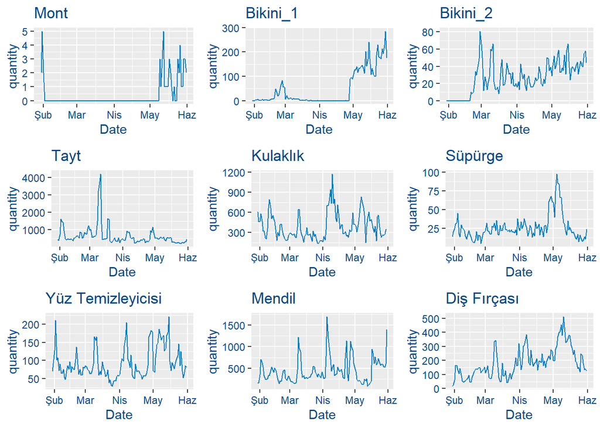

```r
par(mfrow=c(3,3))
a<-ggplot(data = mont, aes(x = event_date, y = sold_count ,group=1))+
  geom_line(color = '#007cc3') + labs(title = 'Mont', x= "Date", y = "quantity") + theme(text=element_text(color="#004785"),axis.text=element_text(color="#004785"))

b<-ggplot(data = bikini_1, aes(x = event_date, y = sold_count ,group=1))+
  geom_line(color = '#007cc3') + labs(title = 'Bikini_1', x= "Date", y = "quantity") + theme(text=element_text(color="#004785"),axis.text=element_text(color="#004785"))

c<-ggplot(data = bikini_2, aes(x = event_date, y = sold_count ,group=1))+
  geom_line(color = '#007cc3') + labs(title = 'Bikini_2', x= "Date", y = "quantity") + theme(text=element_text(color="#004785"),axis.text=element_text(color="#004785"))

d<-ggplot(data = tayt, aes(x = event_date, y = sold_count ,group=1))+
  geom_line(color = '#007cc3') + labs(title = 'Tayt', x= "Date", y = "quantity") + theme(text=element_text(color="#004785"),axis.text=element_text(color="#004785"))

e<-ggplot(data = kulaklık, aes(x = event_date, y = sold_count ,group=1))+
  geom_line(color = '#007cc3') + labs(title = 'Kulaklık', x= "Date", y = "quantity") + theme(text=element_text(color="#004785"),axis.text=element_text(color="#004785"))

f<-ggplot(data = supurge, aes(x = event_date, y = sold_count ,group=1))+
  geom_line(color = '#007cc3') + labs(title = 'Süpürge', x= "Date", y = "quantity") + theme(text=element_text(color="#004785"),axis.text=element_text(color="#004785"))

g<-ggplot(data = yuz_temizleyicisi, aes(x = event_date, y = sold_count ,group=1))+
  geom_line(color = '#007cc3') + labs(title = 'Yüz Temizleyicisi', x= "Date", y = "quantity") + theme(text=element_text(color="#004785"),axis.text=element_text(color="#004785"))

h<-ggplot(data = mendil, aes(x = event_date, y = sold_count ,group=1))+
  geom_line(color = '#007cc3') + labs(title = 'Mendil', x= "Date", y = "quantity") + theme(text=element_text(color="#004785"),axis.text=element_text(color="#004785"))

j<-ggplot(data = dis_fircasi, aes(x = event_date, y = sold_count ,group=1))+
  geom_line(color = '#007cc3') + labs(title = 'Diş Fırçası', x= "Date", y = "quantity") + theme(text=element_text(color="#004785"),axis.text=element_text(color="#004785"))

grid.arrange(a,b,c,d,e,f,g,h,j ,
             ncol = 3, nrow = 3)
```

The initial visual inspection is that some of the products such as Bikini_2 has monthly seasonality. Furthermore, some products are not sold not at all in certain periods, such as ‘mont’ product is not sold at all between March and May, indicating no stock is available in Trendyol’s website. To interpret the data more carefully, seasonality analysis for different time periods should be done for each product separately.

## Analyzing the seasonality of the sales for each 9 product

Weekly decomposition will be done for products, since yearly and hourly decomposition could not be performed due to granularity of the data. Furthermore, due to selecting data for only 5 months, monthly seasonality couldn’t be done too.

ACF will give information about the ‘q’ parameter of the ARIMA model, i.e the moving average part. Furthermore, PACF will give information about the ‘p’ parameter, i.e the autoregression part. The most probable ‘p’ and ‘q’ parameter will be selected by ACF and PACF analysis and 5 ARIMA models will be tried to find best ARIMA model for each product.

For all products, KPSS test, ACF, PACF and seasonality analysis will be done with the function below:

```r
Seasonality_Analysis <- function(X){
  input_data = X
  len = length(input_data$price)
  KPSS_test= ur.kpss(input_data$sold_count)
  print(summary(KPSS_test))
  acf(input_data$sold_count)
  pacf(input_data$sold_count)
  #weekly decomposition
  df_new <- ts(input_data$sold_count,frequency=7)
  df_additive <- decompose(df_new,type="additive")
  plot(df_additive)

}
```

### Seasonality analysis for all nine Products

Seasonality analyis for ‘Mont Product’:

```r
Seasonality_Analysis(mont)
```

```
##
## #######################
## # KPSS Unit Root Test #
## #######################
##
## Test is of type: mu with 4 lags.
##
## Value of test-statistic is: 0.7966
##
## Critical value for a significance level of:
##                 10pct  5pct 2.5pct  1pct
## critical values 0.347 0.463  0.574 0.739
```

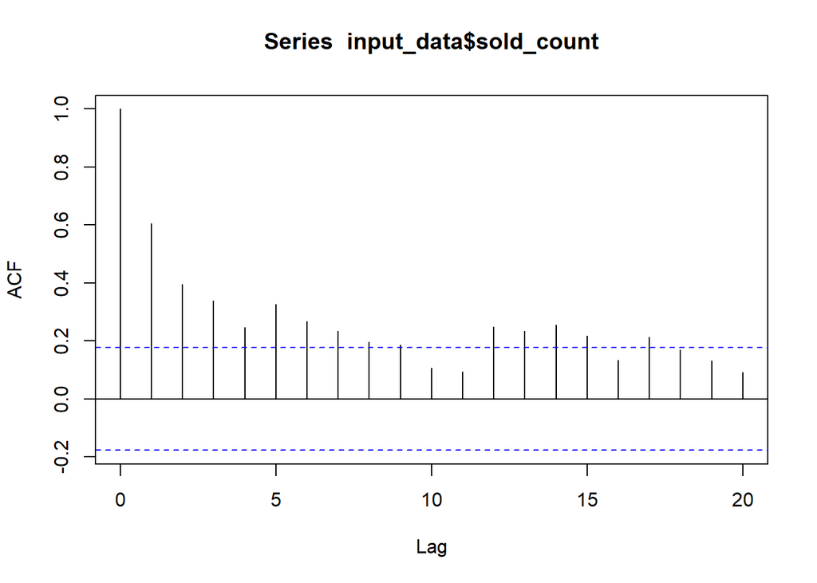

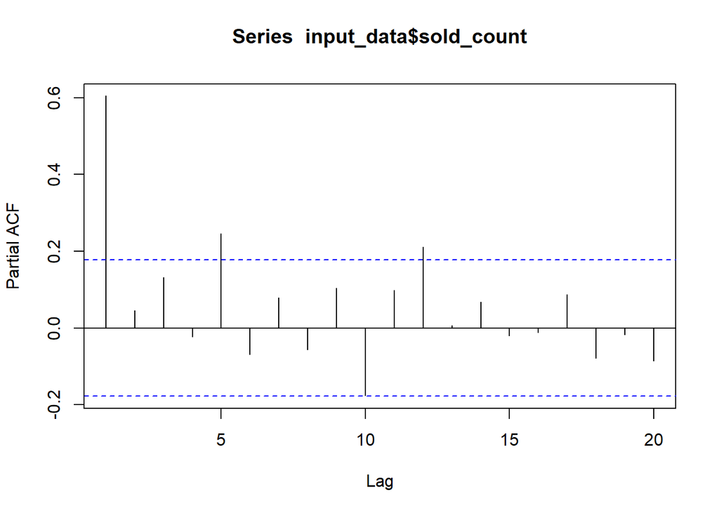

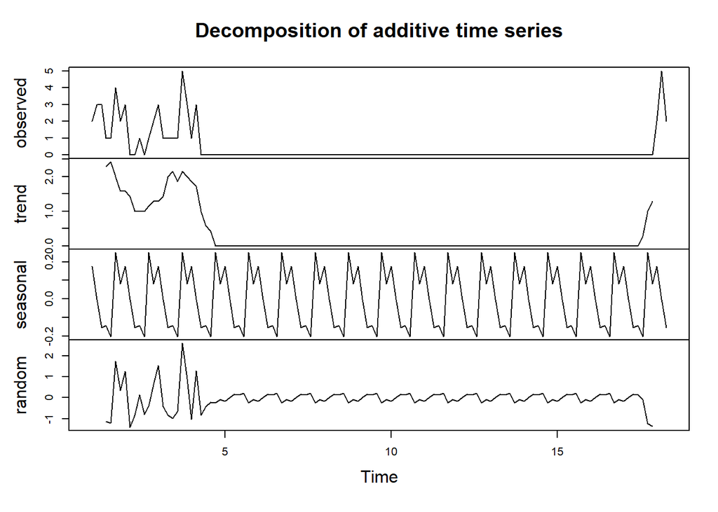

For the ‘Mont’ product, the null hypothesis of the KPSS test is that the data is stationary, and the value of test-statistic exceeds critical values. Therefore, the null hypothesis is rejected and can be concluded that the data is non-stationary. The same conclusion logic will be applied for the rest of the products. For the seasonality, the weekly decomposition shows that the data has weekly seasonal component clearly. Random, trend and the observed data points could not give precise information, since the ‘sold_count’ is zero for at least 3 months, presumably due to ‘out of stock’ status of the product. Best ‘p’ and ‘q’ parameters are 1 and 1-2-3, respectively.

Seasonality analyis for ‘Bikini_1 Product’:

```r
Seasonality_Analysis(bikini_1)
```

```
##
## #######################
## # KPSS Unit Root Test #
## #######################
##
## Test is of type: mu with 4 lags.
##
## Value of test-statistic is: 1.5333
##
## Critical value for a significance level of:
##                 10pct  5pct 2.5pct  1pct
## critical values 0.347 0.463  0.574 0.739
```

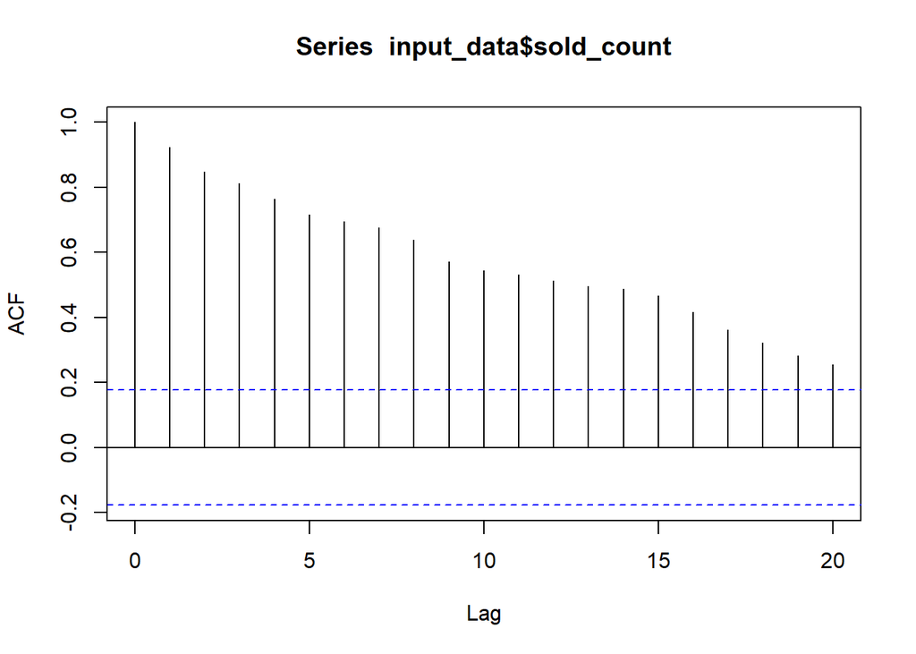

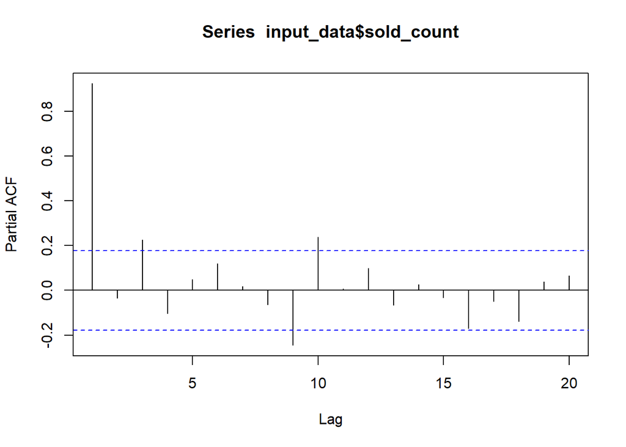

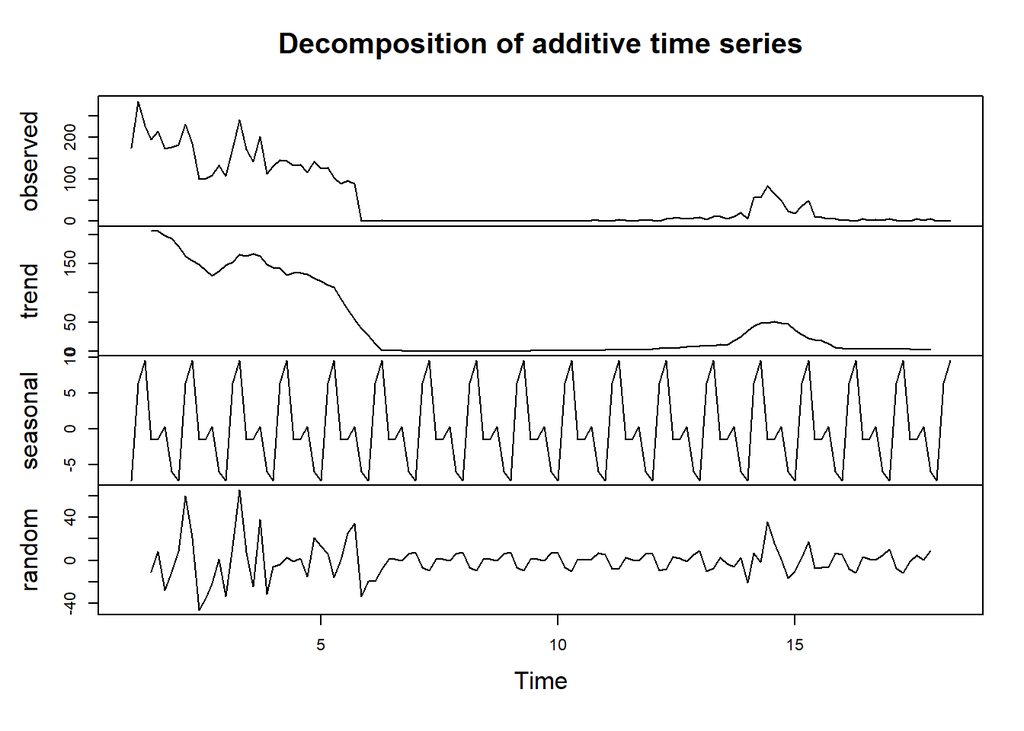

The data is non-stationary. Seasonality is clearly observed; however the rest can not be observed due to most probably ‘out of stock’. Best ‘p’ and ‘q’ parameters are 1 and 1-2-3, respectively. ACF also shows that significantly lags are observed even in 20. day, i.e the data has the trend component.

```r
Seasonality_Analysis(bikini_2)
```

```
##
## #######################
## # KPSS Unit Root Test #
## #######################
##
## Test is of type: mu with 4 lags.
##
## Value of test-statistic is: 1.243
##
## Critical value for a significance level of:
##                 10pct  5pct 2.5pct  1pct
## critical values 0.347 0.463  0.574 0.739
```

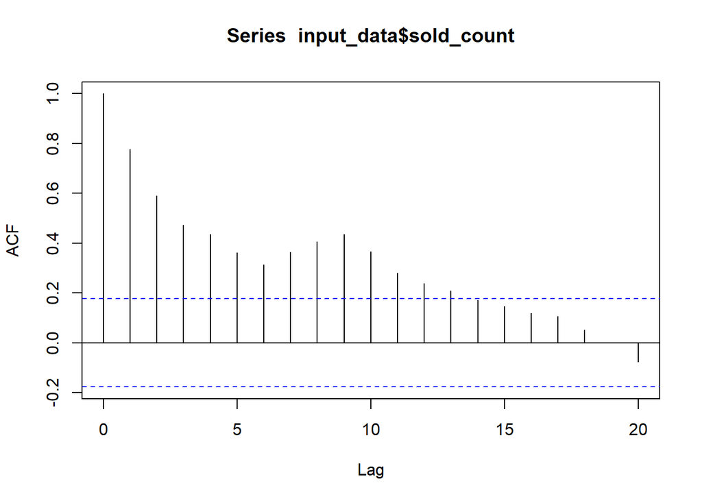

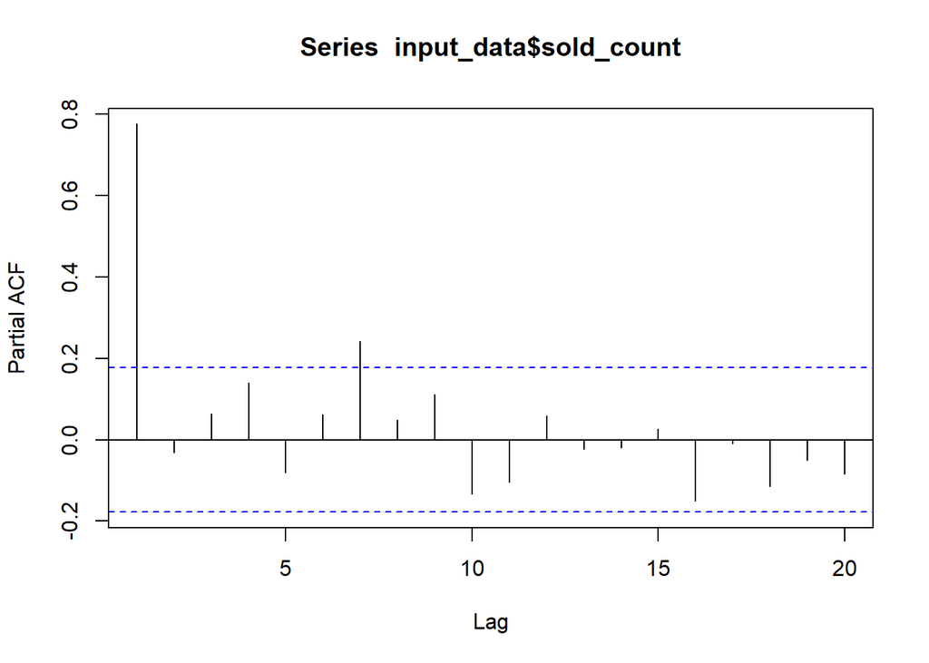

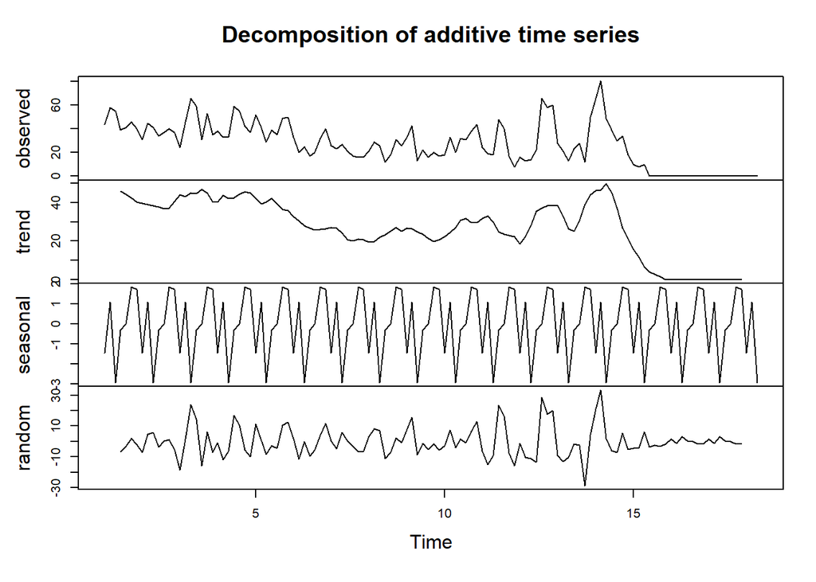

The data is non-stationary. Ignoring the ‘out of stock’ period at the end, seasonality and trend variation is clearly observed. Best ‘p’ and ‘q’ parameters are 1 and 1-2-3, respectively.

```r
Seasonality_Analysis(tayt)
```

```
##
## #######################
## # KPSS Unit Root Test #
## #######################
##
## Test is of type: mu with 4 lags.
##
## Value of test-statistic is: 0.4962
##
## Critical value for a significance level of:
##                 10pct  5pct 2.5pct  1pct
## critical values 0.347 0.463  0.574 0.739
```

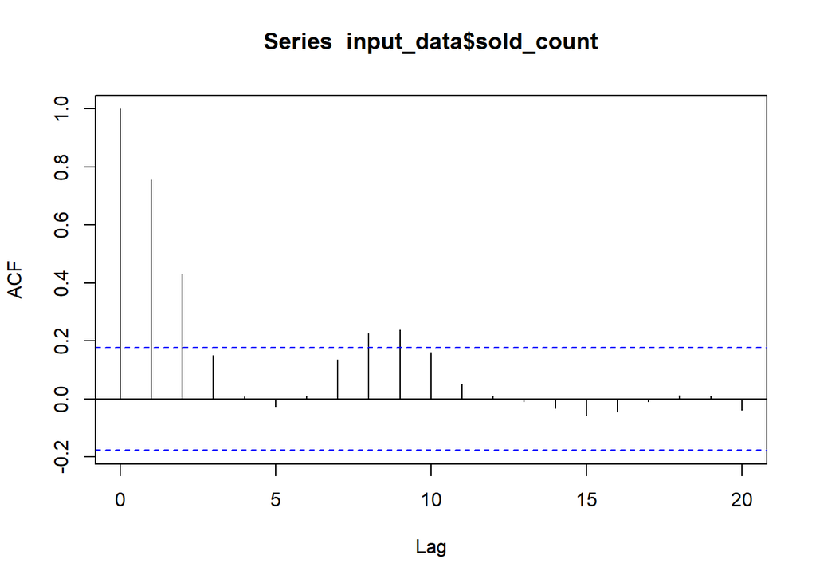

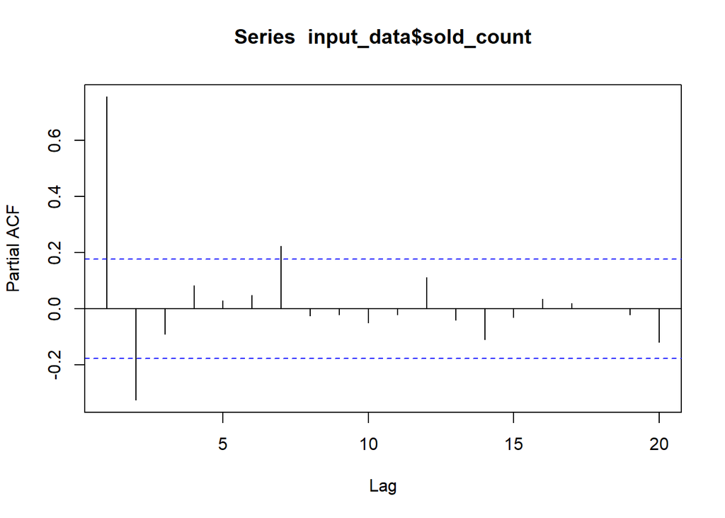

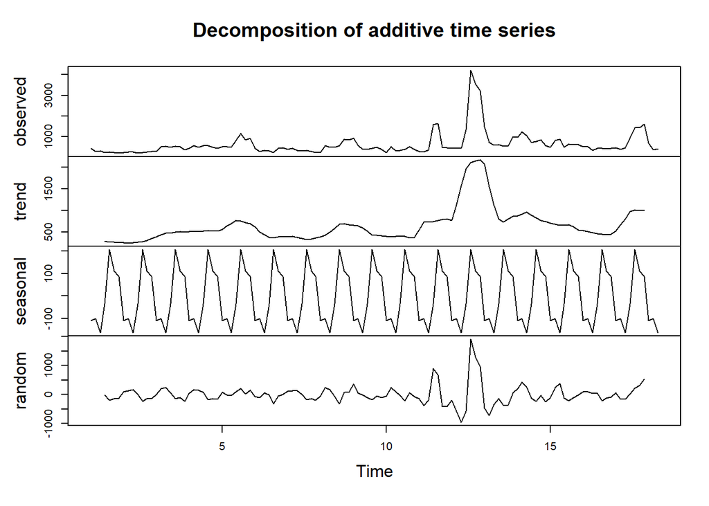

The data is more stationary comparing to the products above (stationary wrt. 2.5 and 1 pct confidence interval). Seasonality is clearly observed. There is a significant peak in the data, can occur from surge in the discount(resulting from special discount days of Trendyol such as ‘Muhteşem Kasım’. Best ‘p’ and ‘q’ parameters are 1 and 1-2-3, respectively. Comparing the random and the actual observation, the data resembles to white noise, meaning that it can’t be predicted well by the statistical models.

```r
Seasonality_Analysis(kulaklık)
```

```
##
## #######################
## # KPSS Unit Root Test #
## #######################
##
## Test is of type: mu with 4 lags.
##
## Value of test-statistic is: 0.1654
##
## Critical value for a significance level of:
##                 10pct  5pct 2.5pct  1pct
## critical values 0.347 0.463  0.574 0.739
```

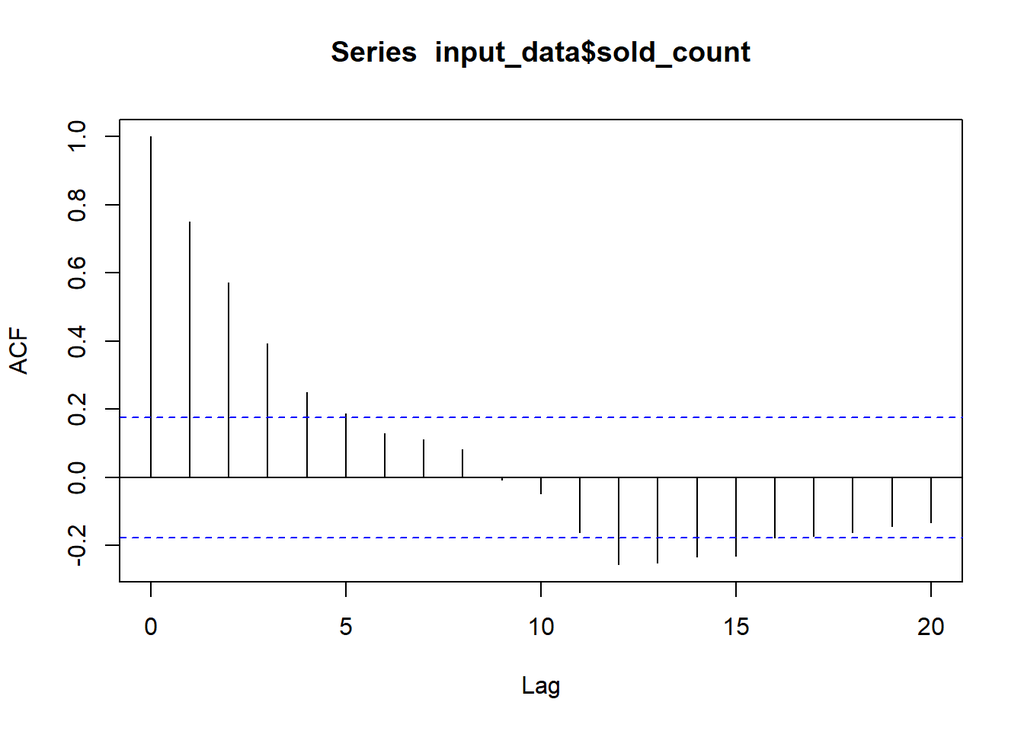

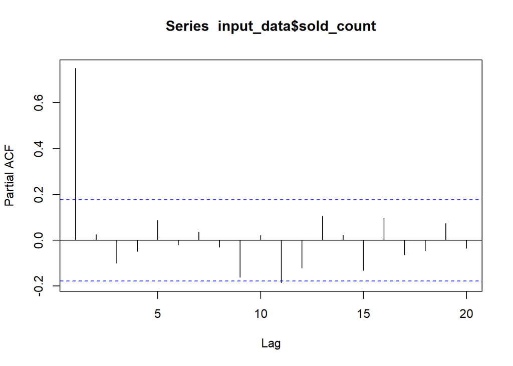

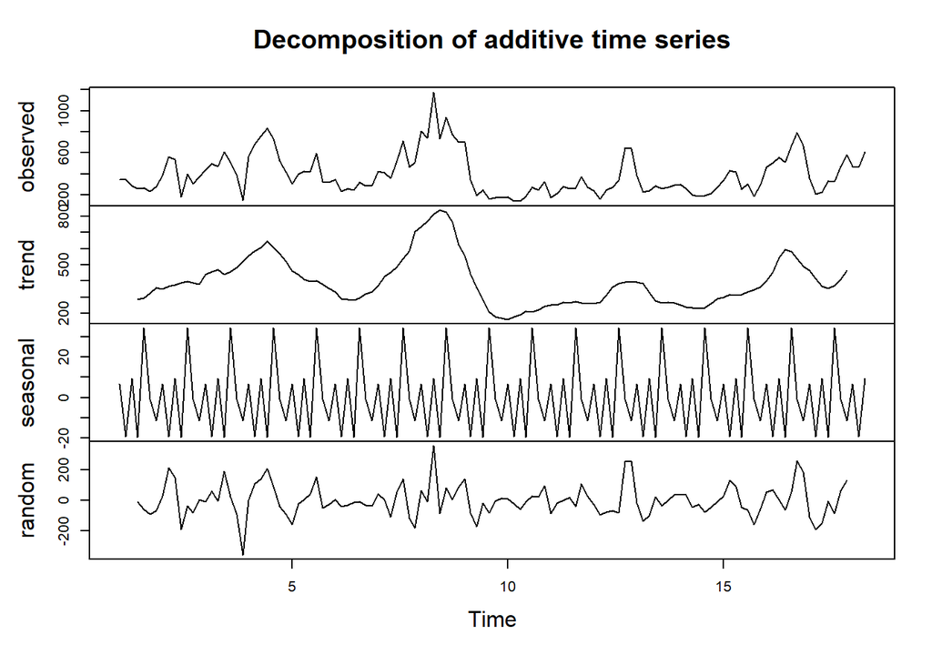

The data is stationary. Seasonality is clearly observed. There is a significant peak in the data, can occur from surge in the discount(resulting from special discount days of Trendyol such as ‘Muhteşem Kasım’. Best ‘p’ and ‘q’ parameters are 1 and 1-2-3, respectively.

```r
Seasonality_Analysis(supurge)
```

```
##
## #######################
## # KPSS Unit Root Test #
## #######################
##
## Test is of type: mu with 4 lags.
##
## Value of test-statistic is: 0.4004
##
## Critical value for a significance level of:
##                 10pct  5pct 2.5pct  1pct
## critical values 0.347 0.463  0.574 0.739
```

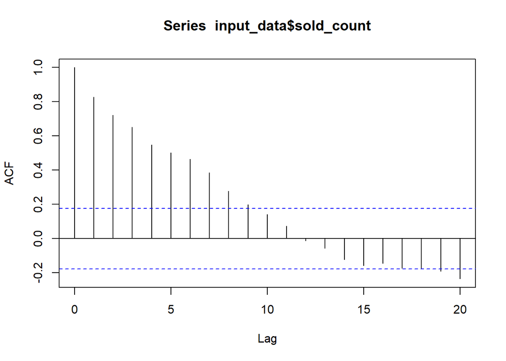

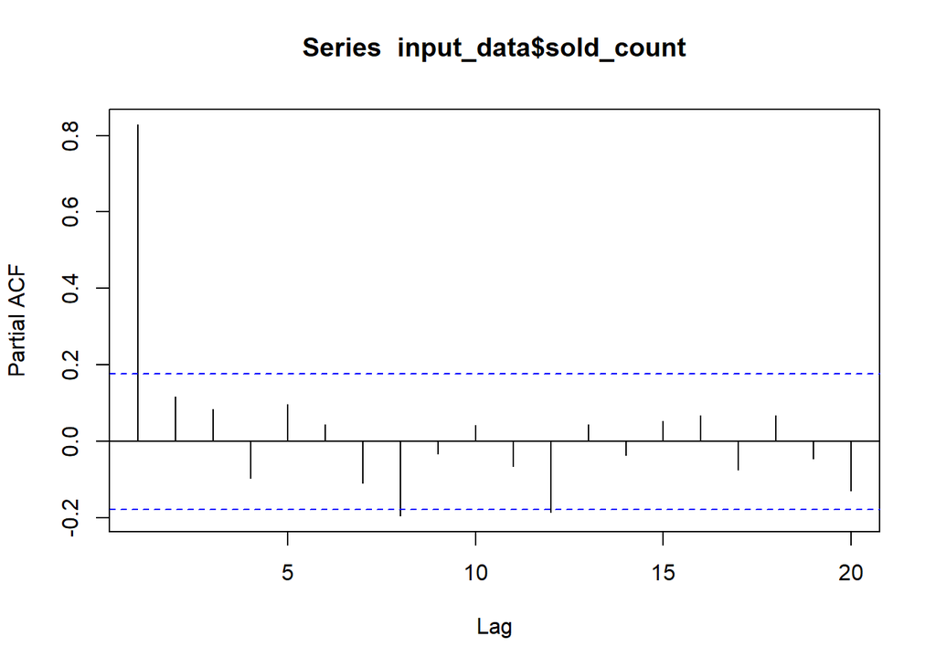

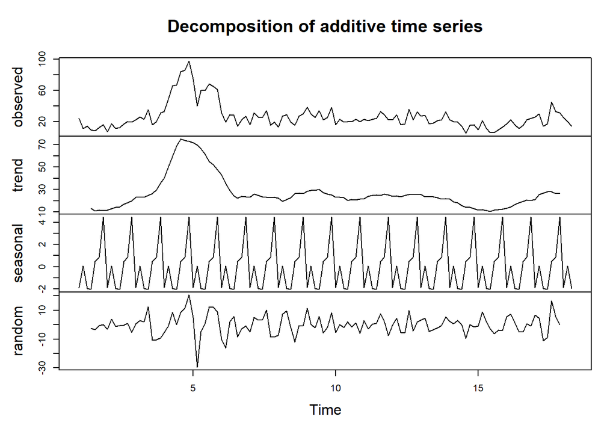

The data is more stationary comparing to the products above (stationary wrt. 5, 2.5 and 1 pct confidence interval). Seasonality is clearly observed. There is a significant peak in the data, can occur from surge in the discount(resulting from special discount days of Trendyol such as ‘Muhteşem Kasım’. Best ‘p’ and ‘q’ parameters are 1 and 1-2-3, respectively.

```r
Seasonality_Analysis(yuz_temizleyicisi)
```

```
##
## #######################
## # KPSS Unit Root Test #
## #######################
##
## Test is of type: mu with 4 lags.
##
## Value of test-statistic is: 0.4218
##
## Critical value for a significance level of:
##                 10pct  5pct 2.5pct  1pct
## critical values 0.347 0.463  0.574 0.739
```

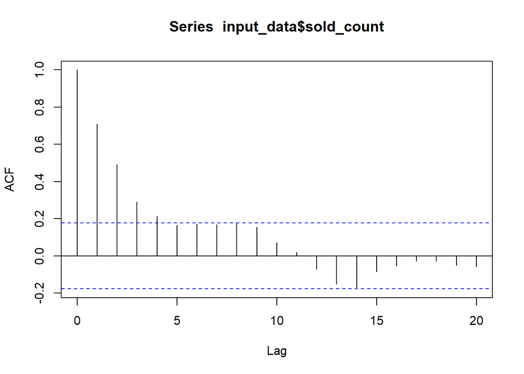

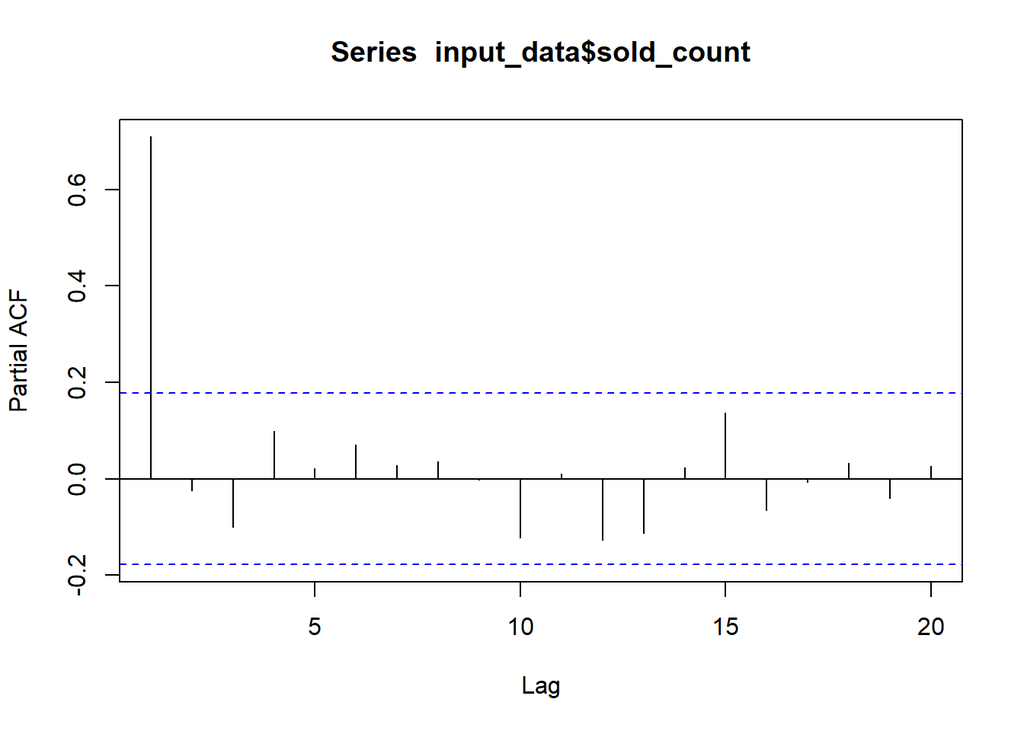

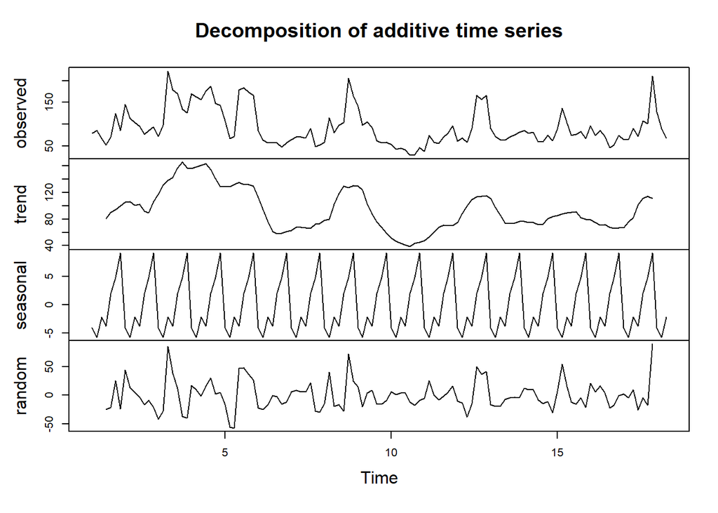

The data is more stationary comparing to the products above (stationary wrt. 5, 2.5 and 1 pct confidence interval). Seasonality is clearly observed. Best ‘p’ and ‘q’ parameters are 1 and 1-2-3, respectively.

```r
Seasonality_Analysis(mendil)
```

```
##
## #######################
## # KPSS Unit Root Test #
## #######################
##
## Test is of type: mu with 4 lags.
##
## Value of test-statistic is: 0.323
##
## Critical value for a significance level of:
##                 10pct  5pct 2.5pct  1pct
## critical values 0.347 0.463  0.574 0.739
```

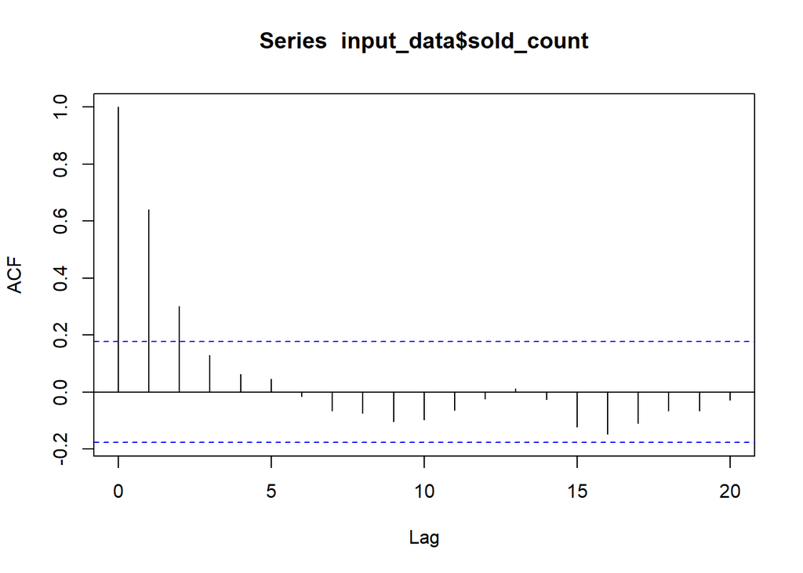

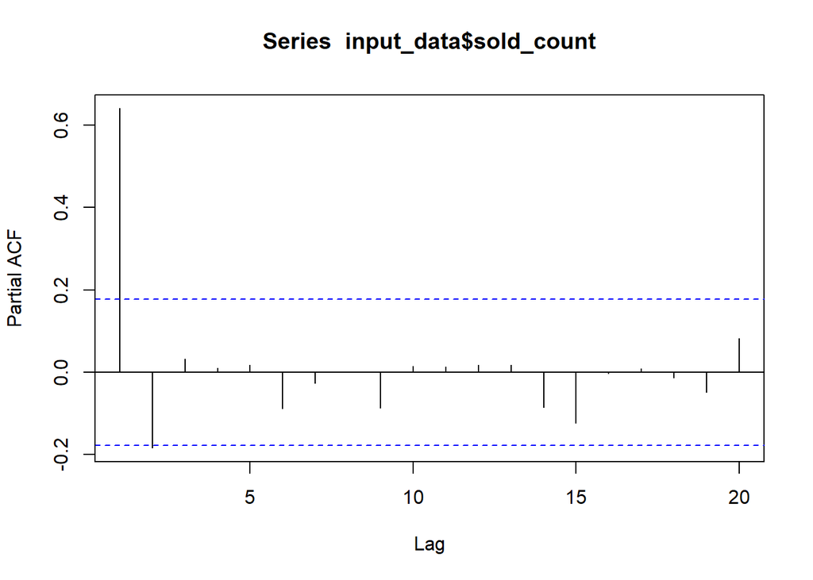

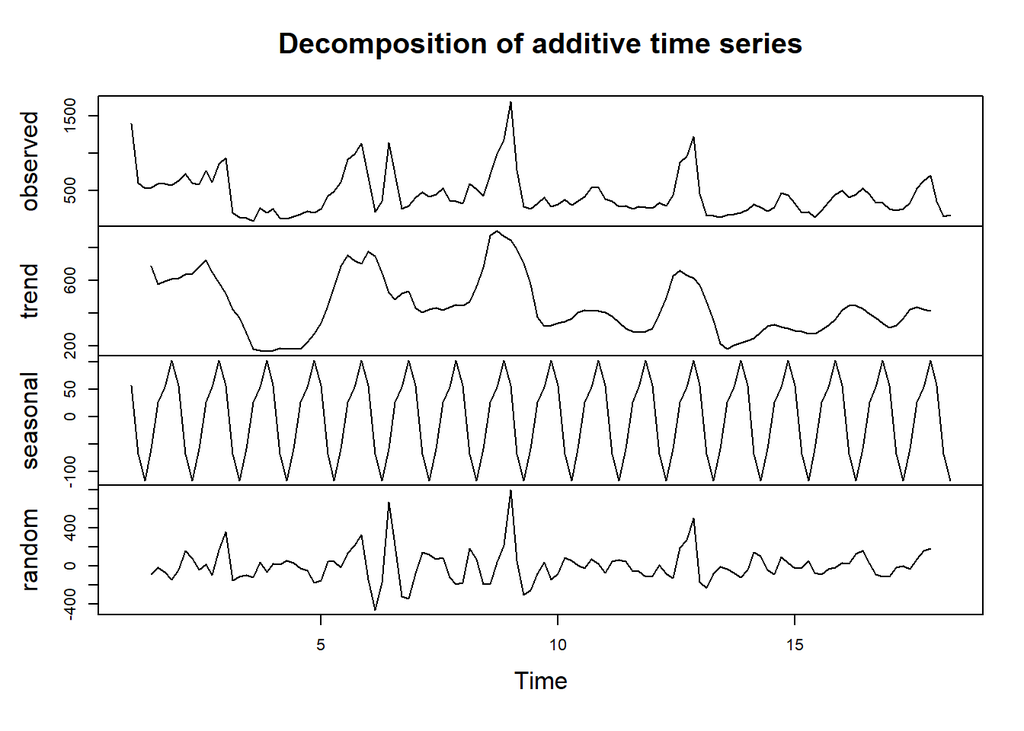

The data is stationary. Seasonality is clearly observed. Best ‘p’ and ‘q’ parameters are 1 and 1-2-3, respectively.

```r
Seasonality_Analysis(dis_fircasi)
```

```
##
## #######################
## # KPSS Unit Root Test #
## #######################
##
## Test is of type: mu with 4 lags.
##
## Value of test-statistic is: 1.296
##
## Critical value for a significance level of:
##                 10pct  5pct 2.5pct  1pct
## critical values 0.347 0.463  0.574 0.739
```

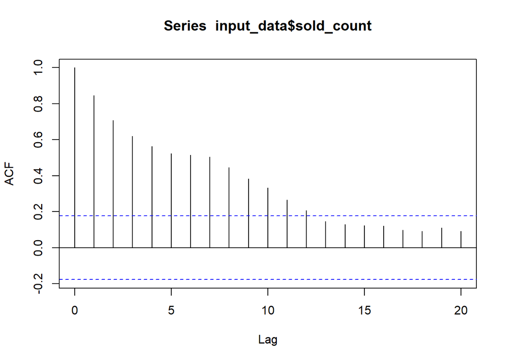

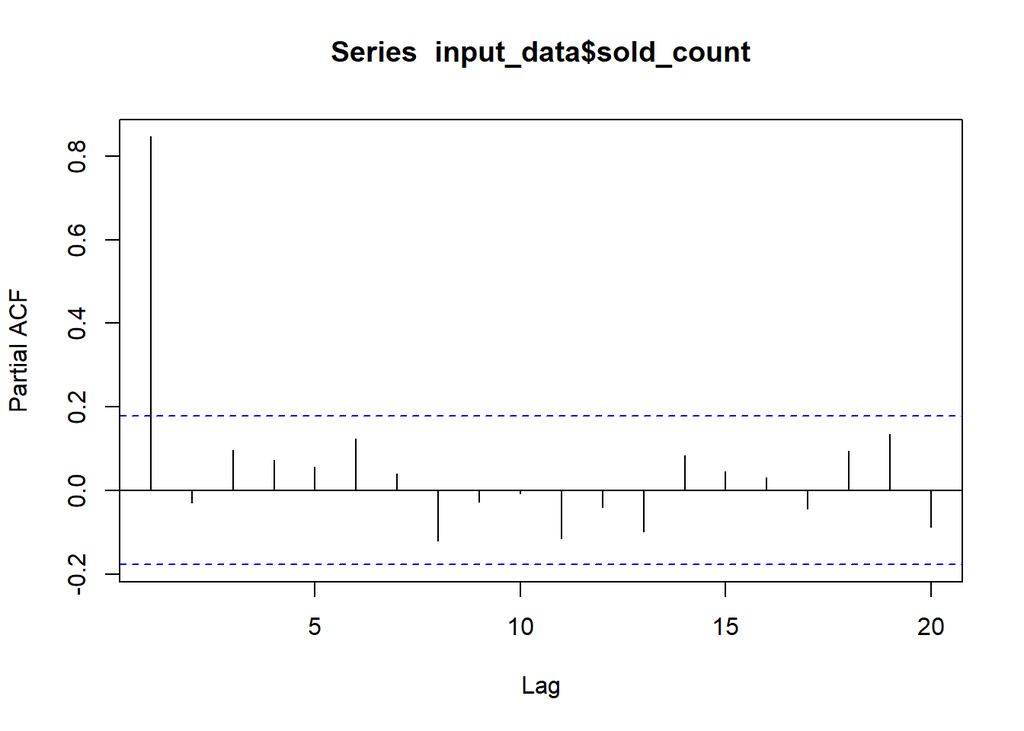

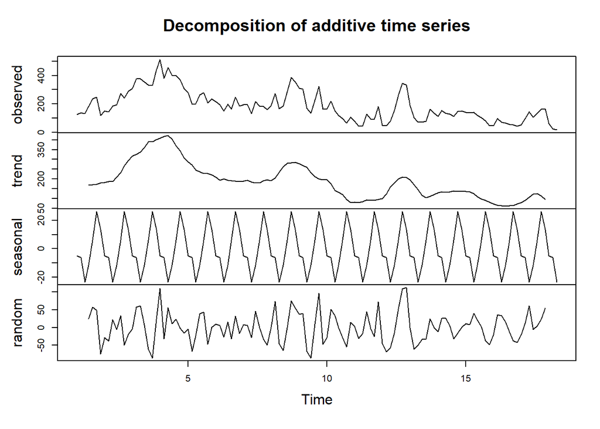

The data is non-stationary. Unlike to other 8 products, it has a decreasing trend over the months. Seasonality is clearly observed. Best ‘p’ and ‘q’ parameters are 1 and 1-2-3, respectively.

## Proposing ARIMA models

We proposed ‘p’ and ‘q’ parameters as 1 and 1-2-3, respectively for all products, since we observed similar ACF and PACF characteristics. Also, differencing of 1 will be tried for each model. The function for decomposing data and creating ARIMA models can be seen below:

```r
ARIMA_proposing <- function(X){
  df_new <- ts(X$sold_count,frequency=7)
  df_additive <- decompose(df_new,type="additive")
  df_deseasoned_detrended <- df_new-df_additive$seasonal-df_additive$trend

  model <- arima(df_deseasoned_detrended, order=c(1,0,1))
  print(model)
  AIC(model)

  model <- arima(df_deseasoned_detrended, order=c(1,1,1))
  print(model)
  AIC(model)

  model <- arima(df_deseasoned_detrended, order=c(1,0,2))
  print(model)
  AIC(model)

  model <- arima(df_deseasoned_detrended, order=c(1,1,2))
  print(model)
  AIC(model)

  model <- arima(df_deseasoned_detrended, order=c(1,0,3))
  print(model)
  AIC(model)

  model <- arima(df_deseasoned_detrended, order=c(1,1,3))
  print(model)
  AIC(model)
}
```

Best ARIMA model for ‘Mont Product’:

```r
ARIMA_proposing(mont)
```

```
##
## Call:
## arima(x = df_deseasoned_detrended, order = c(1, 0, 1))
##
## Coefficients:
##           ar1     ma1  intercept
##       -0.7975  0.9918    -0.0311
## s.e.   0.0832  0.0734     0.0524
##
## sigma^2 estimated as 0.2593:  log likelihood = -87.23,  aic = 182.47
##
## Call:
## arima(x = df_deseasoned_detrended, order = c(1, 1, 1))
##
## Coefficients:
##          ar1      ma1
##       0.0691  -1.0000
## s.e.  0.0978   0.0253
##
## sigma^2 estimated as 0.2879:  log likelihood = -93.89,  aic = 193.79
##
## Call:
## arima(x = df_deseasoned_detrended, order = c(1, 0, 2))
##
## Coefficients:
##          ar1      ma1      ma2  intercept
##       0.0796  -0.3615  -0.6385    -0.0040
## s.e.  0.2732   0.2484   0.2477     0.0023
##
## sigma^2 estimated as 0.2073:  log likelihood = -75.46,  aic = 160.92
##
## Call:
## arima(x = df_deseasoned_detrended, order = c(1, 1, 2))
##
## Coefficients:
##           ar1      ma1      ma2
##       -0.7946  -0.0095  -0.9905
## s.e.   0.0836   0.0700   0.0699
##
## sigma^2 estimated as 0.2617:  log likelihood = -89.26,  aic = 186.52
##
## Call:
## arima(x = df_deseasoned_detrended, order = c(1, 0, 3))
##
## Coefficients:
```

```
##           ar1      ma1      ma2      ma3  intercept
##       -0.1192  -0.1756  -0.7402  -0.0841    -0.0039
## s.e.      NaN      NaN      NaN      NaN     0.0021
##
## sigma^2 estimated as 0.2072:  log likelihood = -75.5,  aic = 163
##
## Call:
## arima(x = df_deseasoned_detrended, order = c(1, 1, 3))
##
## Coefficients:
##          ar1      ma1      ma2     ma3
##       0.1293  -1.3912  -0.2140  0.6072
## s.e.  0.2560   0.2385   0.4621  0.2332
##
## sigma^2 estimated as 0.2117:  log likelihood = -80.37,  aic = 170.74
```

```
## [1] 170.741
```

Best AIC is observed in the ARIMA model (1, 0, 2)

Best ARIMA model for ‘Bikini_1 Product’:

```r
ARIMA_proposing(bikini_1)
```

```
##
## Call:
## arima(x = df_deseasoned_detrended, order = c(1, 0, 1))
##
## Coefficients:
##           ar1     ma1  intercept
##       -0.2688  0.4722    -0.2146
## s.e.   0.2159  0.1858     1.6364
##
## sigma^2 estimated as 231.1:  log likelihood = -480.32,  aic = 968.64
##
## Call:
## arima(x = df_deseasoned_detrended, order = c(1, 1, 1))
##
## Coefficients:
##          ar1      ma1
##       0.1315  -1.0000
## s.e.  0.0930   0.0222
##
## sigma^2 estimated as 239.9:  log likelihood = -480.54,  aic = 967.08
##
## Call:
## arima(x = df_deseasoned_detrended, order = c(1, 0, 2))
##
## Coefficients:
##          ar1      ma1      ma2  intercept
##       0.4177  -0.5629  -0.4371    -0.1258
## s.e.  0.1073   0.0953   0.0928     0.0867
##
## sigma^2 estimated as 173.4:  log likelihood = -465.47,  aic = 940.93
##
## Call:
## arima(x = df_deseasoned_detrended, order = c(1, 1, 2))
##
## Coefficients:
##           ar1      ma1      ma2
##       -0.2571  -0.5329  -0.4671
## s.e.   0.2160   0.1867   0.1857
##
## sigma^2 estimated as 233.2:  log likelihood = -478.91,  aic = 965.81
##
## Call:
## arima(x = df_deseasoned_detrended, order = c(1, 0, 3))
##
## Coefficients:
##          ar1      ma1      ma2      ma3  intercept
##       0.0292  -0.1386  -0.5376  -0.3237    -0.1239
## s.e.  0.3075   0.2951   0.1359   0.1843     0.0786
##
## sigma^2 estimated as 168.8:  log likelihood = -464.05,  aic = 940.09
##
## Call:
## arima(x = df_deseasoned_detrended, order = c(1, 1, 3))
##
## Coefficients:
##          ar1      ma1     ma2     ma3
##       0.4534  -1.5682  0.1417  0.4295
## s.e.  0.1073   0.1094  0.1876  0.0956
##
## sigma^2 estimated as 177.4:  log likelihood = -466.55,  aic = 943.1
```

```
## [1] 943.1041
```

Best AIC is observed in the ARIMA model (1, 0, 3)

Best ARIMA model for ‘Bikini_2 Product’:

```r
ARIMA_proposing(bikini_2)
```

```
##
## Call:
## arima(x = df_deseasoned_detrended, order = c(1, 0, 1))
##
## Coefficients:
##           ar1     ma1  intercept
##       -0.0778  0.3876    -0.1427
## s.e.   0.1795  0.1502     1.1073
##
## sigma^2 estimated as 86.11:  log likelihood = -423.08,  aic = 854.16
##
## Call:
## arima(x = df_deseasoned_detrended, order = c(1, 1, 1))
##
## Coefficients:
##          ar1      ma1
##       0.2319  -1.0000
## s.e.  0.0913   0.0218
##
## sigma^2 estimated as 90.65:  log likelihood = -424.48,  aic = 854.95
##
## Call:
## arima(x = df_deseasoned_detrended, order = c(1, 0, 2))
##
## Coefficients:
##          ar1      ma1      ma2  intercept
##       0.4065  -0.5247  -0.4753    -0.0052
## s.e.  0.1029   0.0828   0.0804     0.0525
##
## sigma^2 estimated as 62.57:  log likelihood = -406.37,  aic = 822.75
##
## Call:
## arima(x = df_deseasoned_detrended, order = c(1, 1, 2))
##
## Coefficients:
##           ar1      ma1      ma2
##       -0.0645  -0.6175  -0.3825
## s.e.   0.1790   0.1507   0.1494
##
## sigma^2 estimated as 86.87:  log likelihood = -422.05,  aic = 852.1
##
## Call:
## arima(x = df_deseasoned_detrended, order = c(1, 0, 3))
##
## Coefficients:
##          ar1     ma1      ma2      ma3  intercept
##       -0.116  0.1390  -0.4389  -0.7001    -0.0036
## s.e.   0.143  0.1099   0.0617   0.1017     0.0496
##
## sigma^2 estimated as 52.73:  log likelihood = -396.88,  aic = 805.77
##
## Call:
## arima(x = df_deseasoned_detrended, order = c(1, 1, 3))
##
## Coefficients:
##           ar1     ma1      ma2      ma3
##       -0.5668  0.0559  -0.5910  -0.4649
## s.e.   0.1556  0.1328   0.1253   0.1273
##
## sigma^2 estimated as 84.1:  log likelihood = -420.13,  aic = 850.26
```

```
## [1] 850.2578
```

Best AIC is observed in the ARIMA model (1, 0, 3)

Best ARIMA model for ‘Tayt Product’:

```r
ARIMA_proposing(tayt)
```

```
##
## Call:
## arima(x = df_deseasoned_detrended, order = c(1, 0, 1))
##
## Coefficients:
##          ar1     ma1  intercept
##       0.1879  0.3977     6.3537
## s.e.  0.1331  0.1077    46.7351
##
## sigma^2 estimated as 86264:  log likelihood = -823.95,  aic = 1655.91
##
## Call:
## arima(x = df_deseasoned_detrended, order = c(1, 1, 1))
##
## Coefficients:
##           ar1     ma1
##       -0.2815  0.3621
## s.e.   0.3937  0.3739
##
## sigma^2 estimated as 130270:  log likelihood = -840.38,  aic = 1686.76
##
## Call:
## arima(x = df_deseasoned_detrended, order = c(1, 0, 2))
##
## Coefficients:
##           ar1     ma1     ma2  intercept
##       -0.2355  0.9154  0.4737     6.7127
## s.e.   0.1707  0.1390  0.1125    50.7810
##
## sigma^2 estimated as 80798:  log likelihood = -820.3,  aic = 1650.59
```

```
##
## Call:
## arima(x = df_deseasoned_detrended, order = c(1, 1, 2))
##
## Coefficients:
##          ar1      ma1      ma2
##       0.2024  -0.6069  -0.3931
## s.e.  0.1336   0.1099   0.1079
##
## sigma^2 estimated as 87017:  log likelihood = -819.18,  aic = 1646.36
##
## Call:
## arima(x = df_deseasoned_detrended, order = c(1, 0, 3))
##
## Coefficients:
##          ar1      ma1      ma2      ma3  intercept
##       0.3125  -0.0505  -0.3673  -0.5821     0.4462
## s.e.  0.1139   0.0874   0.0883   0.0964     2.3406
##
## sigma^2 estimated as 57481:  log likelihood = -802.31,  aic = 1616.62
##
## Call:
## arima(x = df_deseasoned_detrended, order = c(1, 1, 3))
##
## Coefficients:
##           ar1      ma1      ma2      ma3
##       -0.2234  -0.0886  -0.4347  -0.4767
## s.e.   0.1706   0.1402   0.1131   0.1131
##
## sigma^2 estimated as 81496:  log likelihood = -815.44,  aic = 1640.89
```

```
## [1] 1640.887
```

Best AIC is observed in the ARIMA model (1, 0, 3)

Best ARIMA model for ‘Kulaklık Product’:

```r
ARIMA_proposing(kulaklık)
```

```
##
## Call:
## arima(x = df_deseasoned_detrended, order = c(1, 0, 1))
##
## Coefficients:
##          ar1     ma1  intercept
##       0.0186  0.2827    -0.0662
## s.e.  0.2043  0.1825    12.2493
##
## sigma^2 estimated as 10229:  log likelihood = -700.16,  aic = 1408.31
##
## Call:
## arima(x = df_deseasoned_detrended, order = c(1, 1, 1))
##
## Coefficients:
##          ar1      ma1
##       0.2668  -1.0000
## s.e.  0.0909   0.0218
##
## sigma^2 estimated as 10522:  log likelihood = -697.81,  aic = 1401.61
##
## Call:
## arima(x = df_deseasoned_detrended, order = c(1, 0, 2))
##
## Coefficients:
##          ar1      ma1      ma2  intercept
##       0.5128  -0.5763  -0.4236    -0.0162
## s.e.  0.0950   0.0849   0.0825     0.6866
##
## sigma^2 estimated as 7888:  log likelihood = -686.8,  aic = 1383.6
##
## Call:
## arima(x = df_deseasoned_detrended, order = c(1, 1, 2))
##
## Coefficients:
##          ar1      ma1      ma2
##       0.0354  -0.7252  -0.2747
## s.e.  0.2030   0.1822   0.1810
##
## sigma^2 estimated as 10318:  log likelihood = -696.72,  aic = 1401.45
##
## Call:
## arima(x = df_deseasoned_detrended, order = c(1, 0, 3))
##
## Coefficients:
##          ar1      ma1      ma2      ma3  intercept
##       0.2527  -0.2700  -0.3010  -0.4289     0.0246
## s.e.  0.1398   0.1177   0.1104   0.1322     0.6552
##
## sigma^2 estimated as 7246:  log likelihood = -682.02,  aic = 1376.04
##
## Call:
## arima(x = df_deseasoned_detrended, order = c(1, 1, 3))
##
## Coefficients:
##           ar1     ma1      ma2      ma3
##       -0.8867  0.2250  -0.8818  -0.3432
## s.e.   0.2377  0.2368   0.1999   0.0901
##
## sigma^2 estimated as 10142:  log likelihood = -695.75,  aic = 1401.49
```

```
## [1] 1401.495
```

Best AIC is observed in the ARIMA model (1, 0, 3)

Best ARIMA model for ‘Süpürge Product’:

```r
ARIMA_proposing(supurge)
```

```
##
## Call:
## arima(x = df_deseasoned_detrended, order = c(1, 0, 1))
##
## Coefficients:
##           ar1     ma1  intercept
##       -0.2871  0.5393     0.0212
## s.e.   0.2274  0.1934     0.7399
##
## sigma^2 estimated as 44.5:  log likelihood = -384.78,  aic = 777.55
##
## Call:
## arima(x = df_deseasoned_detrended, order = c(1, 1, 1))
##
## Coefficients:
##          ar1      ma1
##       0.1738  -1.0000
## s.e.  0.0921   0.0221
##
## sigma^2 estimated as 46.75:  log likelihood = -386.45,  aic = 778.91
##
## Call:
## arima(x = df_deseasoned_detrended, order = c(1, 0, 2))
##
## Coefficients:
##          ar1      ma1      ma2  intercept
##       0.4453  -0.5214  -0.4786     0.0132
## s.e.  0.1043   0.0954   0.0931     0.0412
##
## sigma^2 estimated as 33.81:  log likelihood = -370.64,  aic = 751.29
##
## Call:
## arima(x = df_deseasoned_detrended, order = c(1, 1, 2))
##
## Coefficients:
##           ar1      ma1      ma2
##       -0.2729  -0.4675  -0.5325
## s.e.   0.2269   0.1937   0.1928
##
## sigma^2 estimated as 44.89:  log likelihood = -384.15,  aic = 776.31
##
## Call:
## arima(x = df_deseasoned_detrended, order = c(1, 0, 3))
##
## Coefficients:
##          ar1      ma1      ma2      ma3  intercept
##       0.2384  -0.2930  -0.4965  -0.2105     0.0126
## s.e.  0.2124   0.2079   0.1063   0.1505     0.0389
##
## sigma^2 estimated as 33.26:  log likelihood = -369.76,  aic = 751.53
##
## Call:
## arima(x = df_deseasoned_detrended, order = c(1, 1, 3))
##
## Coefficients:
##          ar1      ma1     ma2     ma3
##       0.4783  -1.5286  0.0607  0.4699
## s.e.  0.1049   0.1037  0.1867  0.0951
##
## sigma^2 estimated as 34.55:  log likelihood = -372.63,  aic = 755.25
```

```
## [1] 755.2503
```

Best AIC is observed in the ARIMA model (1, 0, 2)

Best ARIMA model for ‘Yüz Temizleyicisi Product’:

```r
ARIMA_proposing(yuz_temizleyicisi)
```

```
##
## Call:
## arima(x = df_deseasoned_detrended, order = c(1, 0, 1))
##
## Coefficients:
##          ar1     ma1  intercept
##       0.0149  0.2607     0.4339
## s.e.  0.2080  0.1847     2.9539
##
## sigma^2 estimated as 619.9:  log likelihood = -537.55,  aic = 1083.1
##
## Call:
## arima(x = df_deseasoned_detrended, order = c(1, 1, 1))
##
## Coefficients:
##          ar1      ma1
##       0.2430  -1.0000
## s.e.  0.0969   0.0227
##
## sigma^2 estimated as 635.3:  log likelihood = -536.42,  aic = 1078.84
##
## Call:
## arima(x = df_deseasoned_detrended, order = c(1, 0, 2))
##
## Coefficients:
##          ar1     ma1      ma2  intercept
##       0.4495  -0.586  -0.4140     0.0164
## s.e.  0.1037   0.091   0.0887     0.1478
##
## sigma^2 estimated as 466:  log likelihood = -522.79,  aic = 1055.57
##
## Call:
## arima(x = df_deseasoned_detrended, order = c(1, 1, 2))
##
## Coefficients:
##          ar1      ma1      ma2
##       0.0322  -0.7468  -0.2532
## s.e.  0.2064   0.1840   0.1827
##
## sigma^2 estimated as 625.3:  log likelihood = -535.54,  aic = 1079.08
##
## Call:
## arima(x = df_deseasoned_detrended, order = c(1, 0, 3))
##
## Coefficients:
##          ar1      ma1      ma2      ma3  intercept
##       0.0770  -0.1224  -0.3801  -0.4975     0.0080
## s.e.  0.1922   0.1741   0.1084   0.1116     0.1407
##
## sigma^2 estimated as 415.8:  log likelihood = -516.36,  aic = 1044.72
##
## Call:
## arima(x = df_deseasoned_detrended, order = c(1, 1, 3))
##
## Coefficients:
##           ar1     ma1      ma2      ma3
##       -0.6627  0.0450  -0.6302  -0.4148
## s.e.   0.2160  0.2068   0.1654   0.1072
##
## sigma^2 estimated as 600.4:  log likelihood = -533.18,  aic = 1076.36
```

```
## [1] 1076.363
```

Best AIC is observed in the ARIMA model (1, 0, 3)

Best ARIMA model for ‘Mendil Product’:

```r
ARIMA_proposing(mendil)
```

```
##
## Call:
## arima(x = df_deseasoned_detrended, order = c(1, 0, 1))
##
## Coefficients:
##           ar1     ma1  intercept
##       -0.0684  0.5721     0.9858
## s.e.   0.1426  0.1049    20.9777
##
## sigma^2 estimated as 23696:  log likelihood = -748.99,  aic = 1505.99
##
## Call:
## arima(x = df_deseasoned_detrended, order = c(1, 1, 1))
##
## Coefficients:
##          ar1      ma1
##       0.3094  -1.0000
## s.e.  0.0898   0.0224
##
## sigma^2 estimated as 27372:  log likelihood = -752.73,  aic = 1511.46
##
## Call:
## arima(x = df_deseasoned_detrended, order = c(1, 0, 2))
##
## Coefficients:
##          ar1      ma1      ma2  intercept
##       0.4376  -0.3687  -0.6313    -0.0757
## s.e.  0.0953   0.0696   0.0675     1.0184
##
## sigma^2 estimated as 17445:  log likelihood = -733,  aic = 1476.01
##
## Call:
## arima(x = df_deseasoned_detrended, order = c(1, 1, 2))
##
## Coefficients:
##           ar1      ma1      ma2
##       -0.0567  -0.4313  -0.5687
## s.e.   0.1432   0.1074   0.1058
##
## sigma^2 estimated as 23902:  log likelihood = -745.03,  aic = 1498.05
##
## Call:
## arima(x = df_deseasoned_detrended, order = c(1, 0, 3))
##
## Coefficients:
##          ar1      ma1      ma2      ma3  intercept
##       0.1625  -0.0173  -0.6108  -0.3720    -0.0882
## s.e.  0.1536   0.1338   0.0877   0.1082     0.9599
##
## sigma^2 estimated as 16300:  log likelihood = -729.17,  aic = 1470.33
##
## Call:
## arima(x = df_deseasoned_detrended, order = c(1, 1, 3))
##
## Coefficients:
##           ar1     ma1      ma2      ma3
##       -0.8711  0.4486  -0.9192  -0.5293
## s.e.   0.1931  0.1941   0.1046   0.1129
##
## sigma^2 estimated as 23695:  log likelihood = -744.5,  aic = 1499
```

```
## [1] 1499.002
```

Best AIC is observed in the ARIMA model (1, 0, 3)

Best ARIMA model for ‘Diş Fırçası Product’:

```r
ARIMA_proposing(dis_fircasi)
```

```
##
## Call:
## arima(x = df_deseasoned_detrended, order = c(1, 0, 1))
##
## Coefficients:
##           ar1     ma1  intercept
##       -0.1234  0.4415     1.2884
## s.e.   0.1957  0.1660     4.8151
##
## sigma^2 estimated as 1639:  log likelihood = -593.96,  aic = 1195.91
##
## Call:
## arima(x = df_deseasoned_detrended, order = c(1, 1, 1))
##
## Coefficients:
##          ar1      ma1
##       0.2390  -1.0000
## s.e.  0.0917   0.0221
##
## sigma^2 estimated as 1729:  log likelihood = -593.98,  aic = 1193.97
##
## Call:
## arima(x = df_deseasoned_detrended, order = c(1, 0, 2))
##
## Coefficients:
##          ar1      ma1      ma2  intercept
##       0.4590  -0.5111  -0.4889     0.1899
## s.e.  0.1006   0.0861   0.0838     0.2580
##
## sigma^2 estimated as 1239:  log likelihood = -579.51,  aic = 1169.02
```

```
##
## Call:
## arima(x = df_deseasoned_detrended, order = c(1, 1, 2))
##
## Coefficients:
##           ar1      ma1      ma2
##       -0.1092  -0.5648  -0.4352
## s.e.   0.1954   0.1667   0.1655
##
## sigma^2 estimated as 1653:  log likelihood = -591.46,  aic = 1190.92
##
## Call:
## arima(x = df_deseasoned_detrended, order = c(1, 0, 3))
##
## Coefficients:
##          ar1      ma1      ma2      ma3  intercept
##       0.0602  -0.0526  -0.4849  -0.4625     0.1626
## s.e.  0.1793   0.1553   0.0827   0.1349     0.2342
##
## sigma^2 estimated as 1159:  log likelihood = -575.8,  aic = 1163.61
##
## Call:
## arima(x = df_deseasoned_detrended, order = c(1, 1, 3))
##
## Coefficients:
```

```
##           ar1      ma1      ma2      ma3
##       -0.3053  -0.3435  -0.5499  -0.1066
## s.e.      NaN      NaN      NaN      NaN
##
## sigma^2 estimated as 1659:  log likelihood = -591.62,  aic = 1193.25
```

```
## [1] 1193.248
```

Best AIC is observed in the ARIMA model (1, 0, 3)

The ARIMA models with (1,0,3) parameters are the best performers in the most of the Trendyol products in terms of AIC.